# JSaldana_LiveSession3assignment

Javier Saldana

September 15, 2018

# **1. GitHub Cloning (20 points):**

## Using Git, clone the following GitHub repository to your local machine: https://github.com/caesar0301/awesome-public-datasets. In RMarkdown, please show the code (commented out, as itâs not R syntax) that you used to create a new directory, navigate to the appropriate directory, and clone the repository to it. One Git command per line, please.

```
#Creates a new directory
javie@Killshot MINGW64 ~
$ mkdir LiveSession3

#Change active directory to 'LiveSession3'
javie@Killshot MINGW64 ~
$ cd LiveSession3

#Clones data set from source provided and copies
javie@Killshot MINGW64 ~/LiveSession3
$ git clone https://github.com/caesar0301/awesome-public-datasets.git
Cloning into 'awesome-public-datasets'...
remote: Counting objects: 1484, done.
remote: Total 1484 (delta 0), reused 0 (delta 0), pack-reused 1484
Receiving objects: 100% (1484/1484), 565.76 KiB | 3.14 MiB/s, done.
Resolving deltas: 100% (866/866), done.
```

# **2. Data Summary (20 points):**

## From this aforementioned cloned repo, please extract titanic.csv.zip. To be clear, this does not have to be done in Git or command line.

### a. In R, please read in titanic.csv via either read.table() or read.csv(), assigning it to df. This dataset follows the passengers aboard the Titanic, including their fees paid, rooms rented, and survivorship status.

```r
df <- read.csv("titanic.csv") #load in data
```

### b. Output the respective count of females and males aboard the Titanic. Plot the frequency of females and males. Be sure to give an accurate title and label the axes.

```r
table(df$Sex) #create table of data.frame
```

```
##
## female   male
##    314    577
```

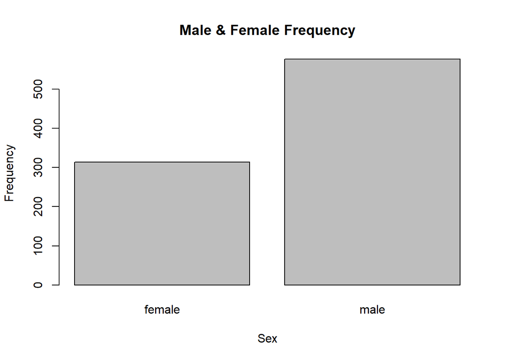

```r
plot(df$Sex) #plot data
title(main = "Male & Female Frequency", xlab = "Sex", ylab = "Frequency")
```

### c. Please use one apply function (to review: swirl() modules 11, 12) to output the means of Age, Fare, and Survival. Make sure the output is a real number for all three means.

```r
Age_Fare_Survival <- df[,c(2,6,10)] #store age, fare, and survived
sapply(Age_Fare_Survival, mean, na.rm = TRUE) #use sapply() to apply mean to all
```

```
##   Survived        Age       Fare
##  0.3838384 29.6991176 32.2042080
```